# Rocket Science RNA-Seq Workflow Template

First/last name (first.last@ucr.edu)

Last update: 31 May, 2018

# 1 Introduction

Users want to provide here background information about the design of their RNA-Seq project.

# 2 Samples and environment settings

## 2.1 Environment settings and input data

Typically, the user wants to record here the sources and versions of the reference genome sequence along with the corresponding annotations. In the provided sample data set all data inputs are stored in a `data` subdirectory and all results will be written to a separate `results` directory, while the `systemPipeRNAseq.Rmd` script and the `targets` file are expected to be located in the parent directory. The R session is expected to run from this parent directory.

To run this sample report, mini sample FASTQ and reference genome files can be downloaded from [here](http://biocluster.ucr.edu/~tgirke/projects/systemPipeR_test_data.zip). The chosen data set SRP010938 contains 18 paired-end (PE) read sets from *Arabidposis thaliana* (Howard et al. 2013). To minimize processing time during testing, each FASTQ file has been subsetted to 90,000-100,000 randomly sampled PE reads that map to the first 100,000 nucleotides of each chromosome of the *A. thalina* genome. The corresponding reference genome sequence (FASTA) and its GFF annotion files (provided in the same download) have been truncated accordingly. This way the entire test sample data set is less than 200MB in storage space. A PE read set has been chosen for this test data set for flexibility, because it can be used for testing both types of analysis routines requiring either SE (single end) reads or PE reads.

## 2.2 Required packages and resources

The `systemPipeR` package needs to be loaded to perform the analysis steps shown in this report (H Backman and Girke 2016).

```r
library(systemPipeR)
```

```r
source("systemPipeRNAseq_Fct.R")
```

## 2.3 Experiment definition provided by `targets` file

The `targets` file defines all FASTQ files and sample comparisons of the analysis workflow.

```r
targets <- read.delim("targets.txt", comment.char = "#")[,1:4]
targets
```

```
##                       FileName SampleName Factor SampleLong
## 1  ./data/SRR446027_1.fastq.gz        M1A     M1  Mock.1h.A
## 2  ./data/SRR446028_1.fastq.gz        M1B     M1  Mock.1h.B
## 3  ./data/SRR446029_1.fastq.gz        A1A     A1   Avr.1h.A
## 4  ./data/SRR446030_1.fastq.gz        A1B     A1   Avr.1h.B
## 5  ./data/SRR446031_1.fastq.gz        V1A     V1   Vir.1h.A
## 6  ./data/SRR446032_1.fastq.gz        V1B     V1   Vir.1h.B
## 7  ./data/SRR446033_1.fastq.gz        M6A     M6  Mock.6h.A
## 8  ./data/SRR446034_1.fastq.gz        M6B     M6  Mock.6h.B
## 9  ./data/SRR446035_1.fastq.gz        A6A     A6   Avr.6h.A
## 10 ./data/SRR446036_1.fastq.gz        A6B     A6   Avr.6h.B
## 11 ./data/SRR446037_1.fastq.gz        V6A     V6   Vir.6h.A
## 12 ./data/SRR446038_1.fastq.gz        V6B     V6   Vir.6h.B
## 13 ./data/SRR446039_1.fastq.gz       M12A    M12 Mock.12h.A
## 14 ./data/SRR446040_1.fastq.gz       M12B    M12 Mock.12h.B
## 15 ./data/SRR446041_1.fastq.gz       A12A    A12  Avr.12h.A
## 16 ./data/SRR446042_1.fastq.gz       A12B    A12  Avr.12h.B
## 17 ./data/SRR446043_1.fastq.gz       V12A    V12  Vir.12h.A
## 18 ./data/SRR446044_1.fastq.gz       V12B    V12  Vir.12h.B
```

# 3 Read preprocessing

## 3.1 Read quality filtering and trimming

```r
library(BBmisc) # Defines suppressAll()
args <- systemArgs(sysma="param/trim.param", mytargets="targets.txt")
filterFct <- function(fq, cutoff=20, Nexceptions=0) {
    qcount <- rowSums(as(quality(fq), "matrix") <= cutoff)
    fq[qcount <= Nexceptions] # Retains reads where Phred scores are >= cutoff with N exceptions
}
suppressAll(preprocessReads(args=args, Fct="filterFct(fq, cutoff=20, Nexceptions=1)",
                batchsize=100000, overwrite=TRUE, compress=TRUE))
writeTargetsout(x=args, file="targets_trim.txt", overwrite=TRUE)
```

```
##   Written content of 'targetsout(x)' to file: targets_trim.txt
```

## 3.2 FASTQ quality report

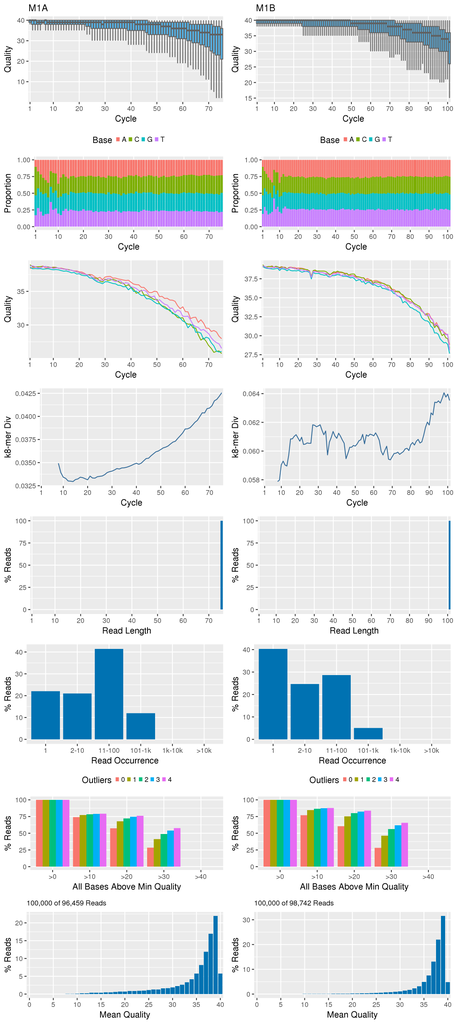

```r
args <- systemArgs(sysma="param/tophat.param", mytargets="targets.txt")
fqlist <- seeFastq(fastq=infile1(args)[1:2], batchsize=100000, klength=8)
png("./results/fastqReport.png", height=18, width=4*length(fqlist), units="in", res=300)
seeFastqPlot(fqlist)
dev.off()
```

# 4 Alignments

## 4.1 Read mapping with `HISAT2`

The NGS reads of this project will be aligned against the reference genome sequence using `Bowtie2/HISAT2` (Kim et al. 2013; Langmead and Salzberg 2012). The parameter settings of the aligner are defined in the `hisat2.param` file.

```r
args <- systemArgs(sysma="param/hisat2.param", mytargets="targets.txt")
sysargs(args)[1] # Command-line parameters for first FASTQ file
```

```
##                                                                                                                                                                                                                                                                                                        M1…
## "hisat2 -p 4 -k 1 --min-intronlen 30 --max-intronlen 3000 -S /bigdata/girkelab/tgirke/GEN242_2018/today/rnaseq/results/SRR446027_1.fastq.gz.hisat.sam /bigdata/girkelab/tgirke/GEN242_2018/today/rnaseq/data/tair10.fasta -U /bigdata/girkelab/tgirke/GEN242_2018/today/rnaseq/data/SRR446027_1.fastq.gz …
```

```r
moduleload(modules(args))
system("hisat2-build ./data/tair10.fasta ./data/tair10.fasta")
resources <- list(walltime="2:00:00", ntasks=1, ncpus=cores(args), memory="10G")
reg <- clusterRun(args, conffile=".BatchJobs.R", template="slurm.tmpl", Njobs=18, runid="01",
                  resourceList=resources)
waitForJobs(reg)
```

```
## [1] TRUE
```

Check whether all BAM files have been created

```r
file.exists(outpaths(args))
```

```
##  [1] TRUE TRUE TRUE TRUE TRUE TRUE TRUE TRUE TRUE TRUE TRUE TRUE TRUE TRUE TRUE TRUE TRUE TRUE
```

## 4.2 Read and alignment stats

The following provides an overview of the number of reads in each sample and how many of them aligned to the reference.

```r
read_statsDF <- alignStats(args=args)
write.table(read_statsDF, "results/alignStats.xls", row.names=FALSE, quote=FALSE, sep="\t")
read_statsDF
```

```
##      FileName Nreads Nalign Perc_Aligned Nalign_Primary Perc_Aligned_Primary
## M1A       M1A  96459  93537     96.97073          93537             96.97073
## M1B       M1B  98742  89340     90.47822          89340             90.47822
## A1A       A1A  94935  92185     97.10328          92185             97.10328
## A1B       A1B  94427  86487     91.59139          86487             91.59139
## V1A       V1A  99366  88685     89.25085          88685             89.25085
## V1B       V1B  97771  95939     98.12623          95939             98.12623
## M6A       M6A  98617  96319     97.66977          96319             97.66977
## M6B       M6B  90452  86871     96.04099          86871             96.04099
## A6A       A6A  91570  89663     97.91744          89663             97.91744
## A6B       A6B  98289  94981     96.63441          94981             96.63441
## V6A       V6A  97102  94437     97.25546          94437             97.25546
## V6B       V6B  99207  94213     94.96608          94213             94.96608
## M12A     M12A  99717  95346     95.61659          95346             95.61659
## M12B     M12B  94477  88686     93.87047          88686             93.87047
## A12A     A12A  93961  91359     97.23077          91359             97.23077
## A12B     A12B  99895  94022     94.12083          94022             94.12083
## V12A     V12A  96961  94027     96.97404          94027             96.97404
## V12B     V12B  90503  85346     94.30185          85346             94.30185
```

## 4.3 Create symbolic links for viewing BAM files in IGV

The `symLink2bam` function creates symbolic links to view the BAM alignment files in a genome browser such as IGV. The corresponding URLs are written to a file with a path specified under `urlfile` in the `results` directory.

```r
symLink2bam(sysargs=args, htmldir=c("~/.html/", "gen242/today/"),
            urlbase="http://biocluster.ucr.edu/~tgirke/",
            urlfile="./results/IGVurl.txt")
```

# 5 Read quantification

## 5.1 Read counting with `summarizeOverlaps` in parallel mode using multiple cores

Reads overlapping with annotation ranges of interest are counted for each sample using the `summarizeOverlaps` function (Lawrence et al. 2013). The read counting is preformed for exonic gene regions in a non-strand-specific manner while ignoring overlaps among different genes. Subsequently, the expression count values are normalized by *reads per kp per million mapped reads* (RPKM). The raw read count table (`countDFeByg.xls`) and the correspoding RPKM table (`rpkmDFeByg.xls`) are written to separate files in the directory of this project.

```r
library("GenomicFeatures"); library(BiocParallel)
txdb <- makeTxDbFromGFF(file="data/tair10.gff", format="gff", dataSource="TAIR", organism="Arabidopsis thaliana")
saveDb(txdb, file="./data/tair10.sqlite")
```

```
## TxDb object:
## # Db type: TxDb
## # Supporting package: GenomicFeatures
## # Data source: TAIR
## # Organism: Arabidopsis thaliana
## # Taxonomy ID: 3702
## # miRBase build ID: NA
## # Genome: NA
## # transcript_nrow: 172
## # exon_nrow: 498
## # cds_nrow: 425
## # Db created by: GenomicFeatures package from Bioconductor
## # Creation time: 2018-05-31 15:29:46 -0700 (Thu, 31 May 2018)
## # GenomicFeatures version at creation time: 1.32.0
## # RSQLite version at creation time: 2.1.1
## # DBSCHEMAVERSION: 1.2
```

```r
txdb <- loadDb("./data/tair10.sqlite")
eByg <- exonsBy(txdb, by=c("gene"))
bfl <- BamFileList(outpaths(args), yieldSize=50000, index=character())
counteByg <- summarizeOverlaps(eByg, bfl, mode="Union",
                                               ignore.strand=TRUE,
                                               # preprocess.reads=invertStrand,
                           inter.feature=FALSE,
                                               singleEnd=TRUE)
countDFeByg <- assays(counteByg)$counts
rpkmDFeByg <- apply(countDFeByg, 2, function(x) returnRPKM(counts=x, ranges=eByg))
write.table(countDFeByg, "results/countDFeByg.xls", col.names=NA, quote=FALSE, sep="\t")
write.table(rpkmDFeByg, "results/rpkmDFeByg.xls", col.names=NA, quote=FALSE, sep="\t")
```

Sample of data slice of count table

```r
read.delim("results/countDFeByg.xls", row.names=1, check.names=FALSE)[1:4,1:5]
```

```
##           M1A M1B A1A A1B V1A
## AT1G01010  28 131 100  92 187
## AT1G01020  16  54  37  68  55
## AT1G01030  20  56  37  34  50
## AT1G01040 109 375 270 374 316
```

Sample of data slice of RPKM table

```r
read.delim("results/rpkmDFeByg.xls", row.names=1, check.names=FALSE)[1:4,1:4]
```

```
##                M1A       M1B       A1A       A1B
## AT1G01010 377.9720 1664.2713 1161.8983 1054.8165
## AT1G01020 205.5135  652.7779  409.0615  741.8513
## AT1G01030 239.2264  630.4031  380.9318  345.4184
## AT1G01040 397.1391 1285.8747  846.7329 1157.3781
```

Note, for most statistical differential expression or abundance analysis methods, such as `edgeR` or `DESeq2`, the raw count values should be used as input. The usage of RPKM values should be restricted to specialty applications required by some users, *e.g.* manually comparing the expression levels among different genes or features.

## 5.2 Sample-wise correlation analysis

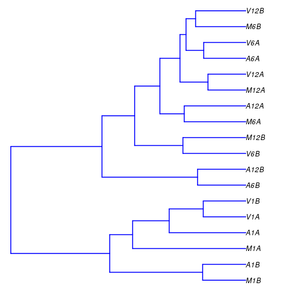

```r
library(DESeq2, quietly=TRUE); library(ape,  warn.conflicts=FALSE)
countDF <- as.matrix(read.table("./results/countDFeByg.xls"))
colData <- data.frame(row.names=targetsin(args)$SampleName, condition=targetsin(args)$Factor)
dds <- DESeqDataSetFromMatrix(countData = countDF, colData = colData, design = ~ condition)
d <- cor(assay(rlog(dds)), method="spearman")
hc <- hclust(dist(1-d))
png("./results/sample_tree.png")
plot.phylo(as.phylo(hc), type="p", edge.col="blue", edge.width=2, show.node.label=TRUE, no.margin=TRUE)
dev.off()
```

Figure 2: Correlation dendrogram of samples

# 6 Analysis of DEGs

The analysis of differentially expressed genes (DEGs) is performed with the glm method of the `edgeR` package (Robinson, McCarthy, and Smyth 2010). The sample comparisons used by this analysis are defined in the header lines of the `targets.txt` file starting with `<CMP>`.

## 6.1 Run `edgeR`

```r
library(edgeR); library(DT)
countDF <- read.delim("results/countDFeByg.xls", row.names=1, check.names=FALSE)
targets <- read.delim("targets.txt", comment="#")
cmp <- readComp(file="targets.txt", format="matrix", delim="-")
edgeDF <- run_edgeR(countDF=countDF, targets=targets, cmp=cmp[[1]], independent=FALSE, mdsplot="")
```

```
## Disp = 0.20126 , BCV = 0.4486
```

```r
edge_round <- na.omit(round(edgeDF, 4))
datatable(edge_round, filter = 'top', options = list(pageLength = 100, scrollX = TRUE, scrollY = "600px", autoWidth = TRUE))
```

|  | M1-A1_logFC | M1-A1_logCPM | M1-A1_LR | M1-A1_PValue | M1-A1_FDR | M1-V1_logFC | M1-V1_logCPM | M1-V1_LR | M1-V1_PValue | M1-V1_FDR | A1-V1_logFC | A1-V1_logCPM | A1-V1_LR | A1-V1_PValue | A1-V1_FDR | M6-A6_logFC | M6-A6_logCPM | M6-A6_LR | M6-A6_PValue | M6-A6_FDR | M6-V6_logFC | M6-V6_logCPM | M6-V6_LR | M6-V6_PValue | M6-V6_FDR | A6-V6_logFC | A6-V6_logCPM | A6-V6_LR | A6-V6_PValue | … |
| --- | --- | --- | --- | --- | --- | --- | --- | --- | --- | --- | --- | --- | --- | --- | --- | --- | --- | --- | --- | --- | --- | --- | --- | --- | --- | --- | --- | --- | --- | --- |
| AT1G01010 | -0.0794 | 10.7731 | 0.0228 | 0.8799 | 1 | -0.7312 | 10.7731 | 1.9489 | 0.1627 | 0.6952 | -0.6518 | 10.7731 | 1.5851 | 0.208 | 0.9384 | -1.2936 | 10.7731 | 5.1354 | 0.0234 | 0.9938 | -1.769 | 10.7731 | 10.067 | 0.0015 | 0.1872 | -0.4755 | 10.7731 | 0.804 | 0.3699 | … |
| AT1G01020 | -0.196 | 9.2403 | 0.1874 | 0.6651 | 1 | -0.1696 | 9.2403 | 0.1399 | 0.7084 | 0.9217 | 0.0263 | 9.2403 | 0.0037 | 0.9516 | 1 | 0.7697 | 9.2403 | 1.5655 | 0.2109 | 0.9938 | -0.9337 | 9.2403 | 3.6219 | 0.057 | 0.5289 | -1.7034 | 9.2403 | 9.4722 | 0.0021 | … |
| AT1G01030 | 0.4535 | 9.1627 | 0.6384 | 0.4243 | 1 | -0.318 | 9.1627 | 0.3279 | 0.5669 | 0.8863 | -0.7715 | 9.1627 | 1.9545 | 0.1621 | 0.9384 | 0.2184 | 9.1627 | 0.0729 | 0.7871 | 1 | -1.5542 | 9.1627 | 5.6711 | 0.0172 | 0.5289 | -1.7726 | 9.1627 | 6.2925 | 0.0121 | … |
| AT1G01040 | -0.0715 | 11.9788 | 0.025 | 0.8744 | 1 | -0.118 | 11.9788 | 0.0681 | 0.7941 | 0.9378 | -0.0465 | 11.9788 | 0.0107 | 0.9176 | 1 | -0.0492 | 11.9788 | 0.0109 | 0.917 | 1 | -1.1221 | 11.9788 | 5.8812 | 0.0153 | 0.5289 | -1.073 | 11.9788 | 5.3085 | 0.0212 | … |
| AT1G01046 | -0.2773 | 6.6547 | 0.0584 | 0.8091 | 1 | -0.6098 | 6.6547 | 0.2954 | 0.5868 | 0.8983 | -0.3325 | 6.6547 | 0.1022 | 0.7493 | 1 | -0.593 | 6.6547 | 0.16 | 0.6892 | 1 | -1.4756 | 6.6547 | 1.3377 | 0.2474 | 0.8166 | -0.8826 | 6.6547 | 0.5233 | 0.4694 | … |
| AT1G01050 | 0.1104 | 11.2013 | 0.0465 | 0.8293 | 1 | -0.4455 | 11.2013 | 0.7704 | 0.3801 | 0.8126 | -0.5559 | 11.2013 | 1.2478 | 0.264 | 0.9384 | 0.5339 | 11.2013 | 1.0739 | 0.3001 | 0.9938 | -0.3078 | 11.2013 | 0.3903 | 0.5322 | 0.9033 | -0.8417 | 11.2013 | 2.751 | 0.0972 | … |
| AT1G01060 | 1.3036 | 9.1732 | 4.3926 | 0.0361 | 0.9395 | 3.2495 | 9.1732 | 21.916 | 0 | 0.0004 | 1.9459 | 9.1732 | 7.9897 | 0.0047 | 0.1458 | 4.9089 | 9.1732 | 4.6003 | 0.032 | 0.9938 | 2.1207 | 9.1732 | 2.9309 | 0.0869 | 0.5778 | -2.7883 | 9.1732 | 1.2105 | 0.2712 | … |
| AT1G01070 | -2.6299 | 6.7186 | 2.0322 | 0.154 | 1 | -4.4254 | 6.7186 | 6.2183 | 0.0126 | 0.4185 | -1.7955 | 6.7186 | 2.052 | 0.152 | 0.9384 | -1.0292 | 6.7186 | 0.5886 | 0.443 | 1 | -0.3137 | 6.7186 | 0.0636 | 0.8009 | 1 | 0.7155 | 6.7186 | 0.3607 | 0.5481 | … |
| AT1G01080 | -0.0301 | 11.0282 | 0.0033 | 0.9539 | 1 | -0.3861 | 11.0282 | 0.5496 | 0.4585 | 0.8863 | -0.356 | 11.0282 | 0.475 | 0.4907 | 0.9384 | 1.1149 | 11.0282 | 3.976 | 0.0462 | 0.9938 | 0.194 | 11.0282 | 0.1374 | 0.7109 | 0.9991 | -0.921 | 11.0282 | 2.784 | 0.0952 | … |
| AT1G01090 | -0.2312 | 12.6961 | 0.2255 | 0.6349 | 1 | -0.3227 | 12.6961 | 0.4393 | 0.5074 | 0.8863 | -0.0915 | 12.6961 | 0.0357 | 0.8502 | 1 | 0.6414 | 12.6961 | 1.6547 | 0.1983 | 0.9938 | -0.0948 | 12.6961 | 0.0378 | 0.8459 | 1 | -0.7361 | 12.6961 | 2.2006 | 0.138 | … |

[output cut: 114 more lines]

Add gene descriptions

```r
library("biomaRt")
m <- useMart("plants_mart", dataset="athaliana_eg_gene", host="plants.ensembl.org")
desc <- getBM(attributes=c("tair_locus", "description"), mart=m)
desc <- desc[!duplicated(desc[,1]),]
descv <- as.character(desc[,2]); names(descv) <- as.character(desc[,1])
edgeDF <- data.frame(edgeDF, Desc=descv[rownames(edgeDF)], check.names=FALSE)
write.table(edgeDF, "./results/edgeRglm_allcomp.xls", quote=FALSE, sep="\t", col.names = NA)
```

## 6.2 Plot DEG results

Filter and plot DEG results for up and down regulated genes. The definition of *up* and *down* is given in the corresponding help file. To open it, type `?filterDEGs` in the R console.

```r
edgeDF <- read.delim("results/edgeRglm_allcomp.xls", row.names=1, check.names=FALSE)
png("results/DEGcounts.png")
DEG_list <- filterDEGs(degDF=edgeDF, filter=c(Fold=2, FDR=20))
dev.off()
```

```r
write.table(DEG_list$Summary, "./results/DEGcounts.xls", quote=FALSE, sep="\t", row.names=FALSE)
```

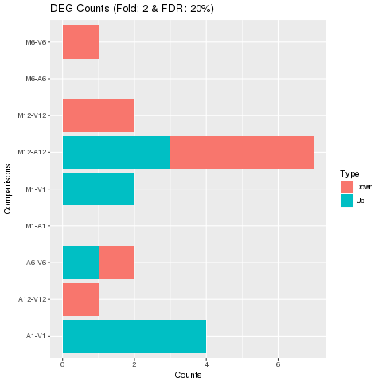

## 6.3 Venn diagrams of DEG sets

The `overLapper` function can compute Venn intersects for large numbers of sample sets (up to 20 or more) and plots 2-5 way Venn diagrams. A useful feature is the possiblity to combine the counts from several Venn comparisons with the same number of sample sets in a single Venn diagram (here for 4 up and down DEG sets).

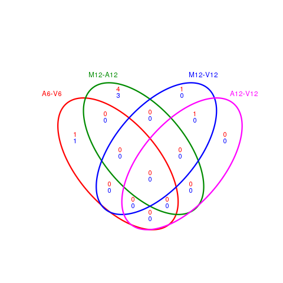

```r
vennsetup <- overLapper(DEG_list$Up[6:9], type="vennsets")
vennsetdown <- overLapper(DEG_list$Down[6:9], type="vennsets")
png("results/vennplot.png")
vennPlot(list(vennsetup, vennsetdown), mymain="", mysub="", colmode=2, ccol=c("blue", "red"))
dev.off()
```

Figure 4: Venn Diagram for 4 Up and Down DEG Sets

# 7 GO term enrichment analysis

## 7.1 Obtain gene-to-GO mappings

The following shows how to obtain gene-to-GO mappings from `biomaRt` (here for *A. thaliana*) and how to organize them for the downstream GO term enrichment analysis. Alternatively, the gene-to-GO mappings can be NA packages or GO annotation files provided by various genome databases. For each annotation this relatively slow preprocessing step needs to be performed only once. Subsequently, the preprocessed data can be loaded with the `load` function as shown in the next subsection.

```r
library("biomaRt")
listMarts() # To choose BioMart database
listMarts(host="plants.ensembl.org")
m <- useMart("plants_mart", host="plants.ensembl.org")
listDatasets(m)
m <- useMart("plants_mart", dataset="athaliana_eg_gene", host="plants.ensembl.org")
listAttributes(m) # Choose data types you want to download
go <- getBM(attributes=c("go_id", "tair_locus", "namespace_1003"), mart=m)
go <- go[go[,3]!="",]; go[,3] <- as.character(go[,3])
go[go[,3]=="molecular_function", 3] <- "F"; go[go[,3]=="biological_process", 3] <- "P"; go[go[,3]=="cellular_component", 3] <- "C"
go[1:4,]
dir.create("./data/GO")
write.table(go, "data/GO/GOannotationsBiomart_mod.txt", quote=FALSE, row.names=FALSE, col.names=FALSE, sep="\t")
catdb <- makeCATdb(myfile="data/GO/GOannotationsBiomart_mod.txt", lib=NULL, org="", colno=c(1,2,3), idconv=NULL)
save(catdb, file="data/GO/catdb.RData")
```

## 7.2 Batch GO term enrichment analysis

```r
library("biomaRt")
load("data/GO/catdb.RData")
edgeDF <- read.delim("results/edgeRglm_allcomp.xls", row.names=1, check.names=FALSE)
DEG_list <- filterDEGs(degDF=edgeDF, filter=c(Fold=2, FDR=50), plot=FALSE)
up_down <- DEG_list$UporDown; names(up_down) <- paste(names(up_down), "_up_down", sep="")
up <- DEG_list$Up; names(up) <- paste(names(up), "_up", sep="")
down <- DEG_list$Down; names(down) <- paste(names(down), "_down", sep="")
DEGlist <- c(up_down, up, down)
DEGlist <- DEGlist[sapply(DEGlist, length) > 20]
BatchResult <- GOCluster_Report(catdb=catdb, setlist=DEGlist, method="all", id_type="gene", CLSZ=2, cutoff=0.9, gocats=c("MF", "BP", "CC"), recordSpecGO=NULL)
```

```
##
##  Processing cluster no A6-V6_up_down with method: "all" (GOHyperGAll)
##
##  Processing cluster no M12-A12_up_down with method: "all" (GOHyperGAll)
```

```r
library("biomaRt")
m <- useMart("plants_mart", dataset="athaliana_eg_gene", host="plants.ensembl.org")
goslimvec <- as.character(getBM(attributes=c("goslim_goa_accession"), mart=m)[,1])
BatchResultslim <- GOCluster_Report(catdb=catdb, setlist=DEGlist, method="slim", id_type="gene", myslimv=goslimvec, CLSZ=10, cutoff=0.01, gocats=c("MF", "BP", "CC"), recordSpecGO=NULL)
```

```
##
##  Processing cluster no A6-V6_up_down with method: "slim" (GOHyperGAll_Subset)
##
##  Processing cluster no M12-A12_up_down with method: "slim" (GOHyperGAll_Subset)
```